# **Milestone 1**

### **Problem Definition**

**The context:** Why is this problem important to solve?

- A major proportion of retail bank profit comes from interests in the form of home loans. Bad loan (NPA) usually eat up a major chunk of profits. Therefore, building a machine model that can automatically check the creditworthiness of a customer with high efficiency and low bias is extremely important.

**The objectives:** What is the intended goal?

- We aim to simplify the decision-making process for home equity lines of credit. The bank's consumer credit department can utilize our model to predict clients who are likely to default on their loan and recommend important features to consider while approving a loan.

**The key questions:** What are the key questions that need to be answered?

- Should we approve a client based on the information he/she provided?
- What kinds of clients are likely to default on their loan?
- What are important features to consider while approving a loan?

**The problem formulation:** What is it that we are trying to solve using data science

- In this research, we will build an empirically derived, statistically sound, and Equal-Credit-Opportunity-Act-complied classification model. The model will be based on the data obtained via the existing loan underwriting process. The model will be built from predictive modeling techniques, but the model created must be interpretable enough to provide a justification for any adverse behavior (rejections).

## **Data Description:**

The Home Equity dataset (HMEQ) contains baseline and loan performance information for 5,960 recent home equity loans. The target (BAD) is a binary variable that indicates whether an applicant has ultimately defaulted or has been severely delinquent. This adverse outcome occurred in 1,189 cases (20 percent). 12 input variables were registered for each applicant.

- **BAD:** 1 = Client defaulted on loan, 0 = loan repaid
- **LOAN:** Amount of loan approved.
- **MORTDUE:** Amount due on the existing mortgage.
- **VALUE:** Current value of the property.
- **REASON:** Reason for the loan request. (HomeImp = home improvement, DebtCon= debt consolidation which means taking out a new loan to pay off other liabilities and consumer debts)
- **JOB:** The type of job that loan applicant has such as manager, self, etc.
- **YOJ:** Years at present job.
- **DEROG:** Number of major derogatory reports (which indicates a serious delinquency or late payments).
- **DELINQ:** Number of delinquent credit lines (a line of credit becomes delinquent when a borrower does not make the minimum required payments 30 to 60 days past the day on which the payments were due).
- **CLAGE:** Age of the oldest credit line in months.
- **NINQ:** Number of recent credit inquiries.
- **CLNO:** Number of existing credit lines.
- **DEBTINC:** Debt-to-income ratio (all your monthly debt payments divided by your gross monthly income. This number is one way lenders measure your ability to manage the monthly payments to repay the money you plan to borrow.

## **Important Notes**

- This notebook can be considered a guide to refer to while solving the problem. The evaluation will be as per the Rubric shared for each Milestone. Unlike previous courses, it does not follow the pattern of the graded questions in different sections. This notebook would give you a direction on what steps need to be taken in order to get a viable solution to the problem. Please note that this is just one way of doing this. There can be other 'creative' ways to solve the problem and we urge you to feel free and explore them as an 'optional' exercise.
- In the notebook, there are markdowns cells called - Observations and Insights. It is a good practice to provide observations and extract insights from the outputs.
- The naming convention for different variables can vary. Please consider the code provided in this notebook as a sample code.
- All the outputs in the notebook are just for reference and can be different if you follow a different approach.
- There are sections called **Think About It** in the notebook that will help you get a better understanding of the reasoning behind a particular technique/step. Interested learners can take alternative approaches if they want to explore different techniques.

### **Import the necessary libraries**

```python
import numpy as np
import pandas as pd
import matplotlib.pyplot as plt
import seaborn as sns
sns.set_theme()

from sklearn.model_selection import train_test_split

from sklearn.linear_model import LogisticRegression

from sklearn import metrics
from sklearn.metrics import confusion_matrix, classification_report,accuracy_score,precision_score,recall_score,f1_score

from sklearn import tree
from sklearn.tree import DecisionTreeClassifier

from sklearn.ensemble import BaggingClassifier
from sklearn.ensemble import RandomForestClassifier

import scipy.stats as stats

from sklearn.model_selection import GridSearchCV


import warnings
warnings.filterwarnings('ignore')
```

### **Read the dataset**

```python
hm=pd.read_csv("hmeq.csv")
```

```python
# Copying data to another variable to avoid any changes to original data
data=hm.copy()
```

### **Print the first and last 5 rows of the dataset**

```python
# Display first five rows
data.head()
```

|  | BAD | LOAN | MORTDUE | VALUE | REASON | JOB | YOJ | DEROG | DELINQ | CLAGE | NINQ | CLNO | DEBTINC |
| --- | --- | --- | --- | --- | --- | --- | --- | --- | --- | --- | --- | --- | --- |
| 0 | 1 | 1100 | 25860.0 | 39025.0 | HomeImp | Other | 10.5 | 0.0 | 0.0 | 94.366667 | 1.0 | 9.0 | NaN |
| 1 | 1 | 1300 | 70053.0 | 68400.0 | HomeImp | Other | 7.0 | 0.0 | 2.0 | 121.833333 | 0.0 | 14.0 | NaN |
| 2 | 1 | 1500 | 13500.0 | 16700.0 | HomeImp | Other | 4.0 | 0.0 | 0.0 | 149.466667 | 1.0 | 10.0 | NaN |
| 3 | 1 | 1500 | NaN | NaN | NaN | NaN | NaN | NaN | NaN | NaN | NaN | NaN | NaN |
| 4 | 0 | 1700 | 97800.0 | 112000.0 | HomeImp | Office | 3.0 | 0.0 | 0.0 | 93.333333 | 0.0 | 14.0 | NaN |

```python
# Display last 5 rows
data.tail()
```

|  | BAD | LOAN | MORTDUE | VALUE | REASON | JOB | YOJ | DEROG | DELINQ | CLAGE | NINQ | CLNO | DEBTINC |
| --- | --- | --- | --- | --- | --- | --- | --- | --- | --- | --- | --- | --- | --- |
| 5955 | 0 | 88900 | 57264.0 | 90185.0 | DebtCon | Other | 16.0 | 0.0 | 0.0 | 221.808718 | 0.0 | 16.0 | 36.112347 |
| 5956 | 0 | 89000 | 54576.0 | 92937.0 | DebtCon | Other | 16.0 | 0.0 | 0.0 | 208.692070 | 0.0 | 15.0 | 35.859971 |
| 5957 | 0 | 89200 | 54045.0 | 92924.0 | DebtCon | Other | 15.0 | 0.0 | 0.0 | 212.279697 | 0.0 | 15.0 | 35.556590 |
| 5958 | 0 | 89800 | 50370.0 | 91861.0 | DebtCon | Other | 14.0 | 0.0 | 0.0 | 213.892709 | 0.0 | 16.0 | 34.340882 |
| 5959 | 0 | 89900 | 48811.0 | 88934.0 | DebtCon | Other | 15.0 | 0.0 | 0.0 | 219.601002 | 0.0 | 16.0 | 34.571519 |

### **Understand the shape of the dataset**

```python
# Check the shape of the data
data.shape
```

```
(5960, 13)
```

**Insights**

- The data consists of **5960 rows and 12 characteristics** for each client (after taking out first column which is our label)
- There are missing value in the dataset and require data cleaning

### **Check the data types of the columns**

```python
# Check info of the data
data.info()
```

```
<class 'pandas.core.frame.DataFrame'>
RangeIndex: 5960 entries, 0 to 5959
Data columns (total 13 columns):
 #   Column   Non-Null Count  Dtype
---  ------   --------------  -----
 0   BAD      5960 non-null   int64
 1   LOAN     5960 non-null   int64
 2   MORTDUE  5442 non-null   float64
 3   VALUE    5848 non-null   float64
 4   REASON   5708 non-null   object
 5   JOB      5681 non-null   object
 6   YOJ      5445 non-null   float64
 7   DEROG    5252 non-null   float64
 8   DELINQ   5380 non-null   float64
 9   CLAGE    5652 non-null   float64
 10  NINQ     5450 non-null   float64
 11  CLNO     5738 non-null   float64
 12  DEBTINC  4693 non-null   float64
dtypes: float64(9), int64(2), object(2)
memory usage: 605.4+ KB
```

**Insights**

- We can see that every column except bad and loan amount have missing values. The Debt-to-income ratio column has more than 1000 missing value.

### **Check for missing values**

```python
# Analyse missing values - Hint: use isnull() function
data.isnull().sum()
```

```
BAD           0
LOAN          0
MORTDUE     518
VALUE       112
REASON      252
JOB         279
YOJ         515
DEROG       708
DELINQ      580
CLAGE       308
NINQ        510
CLNO        222
DEBTINC    1267
dtype: int64
```

```python
# Check the percentage of missing values in the each column.
# Hint: divide the result from the previous code by the number of rows in the dataset
print("% of missing values in the each column")
round(data.isnull().sum()/data.shape[0]*100,3)
```

```
% of missing values in the each column
```

```
BAD         0.000
LOAN        0.000
MORTDUE     8.691
VALUE       1.879
REASON      4.228
JOB         4.681
YOJ         8.641
DEROG      11.879
DELINQ      9.732
CLAGE       5.168
NINQ        8.557
CLNO        3.725
DEBTINC    21.258
dtype: float64
```

**Insights**

- Every column except label and loan has missing value.
- DEROG has ~12% value missing and DEBTINC has ~21% of value missing.

### **Think about it:**

- We found the total number of missing values and the percentage of missing values, which is better to consider?
- What can be the limit for % missing values in a column in order to avoid it and what are the challenges associated with filling them and avoiding them?
1. **Percentage is a better measurement**, it gives a clearer view on how many missing values for each column
2. Dropping too many missing value may lead to **important information loss**. Some rows may only have one or two missing value, avoiding them by dropping them could lead to incomplete information of our analysis.
3. Filling missing value with average, median, mode, etc. could retain important information but could also **create bias** for our analysis. The actual data for the missing value could be very different from the value we filled.

**We can convert the object type columns to categories**

`converting "objects" to "category" reduces the data space required to store the dataframe`

### **Convert the data types**

```python
cols = data.select_dtypes(['object']).columns.tolist()

#adding target variable to this list as this is an classification problem and the target variable is categorical

cols.append('BAD')
```

```python
cols
```

```
['REASON', 'JOB', 'BAD']
```

```python
# Changing the data type of object type column to category. hint use astype() function
for i in cols:
    data[i] = data[i].astype('category')
```

```python
# Checking the info again and the datatype of different variable
data.info()
```

```
<class 'pandas.core.frame.DataFrame'>
RangeIndex: 5960 entries, 0 to 5959
Data columns (total 13 columns):
 #   Column   Non-Null Count  Dtype
---  ------   --------------  -----
 0   BAD      5960 non-null   category
 1   LOAN     5960 non-null   int64
 2   MORTDUE  5442 non-null   float64
 3   VALUE    5848 non-null   float64
 4   REASON   5708 non-null   category
 5   JOB      5681 non-null   category
 6   YOJ      5445 non-null   float64
 7   DEROG    5252 non-null   float64
 8   DELINQ   5380 non-null   float64
 9   CLAGE    5652 non-null   float64
 10  NINQ     5450 non-null   float64
 11  CLNO     5738 non-null   float64
 12  DEBTINC  4693 non-null   float64
dtypes: category(3), float64(9), int64(1)
memory usage: 483.7 KB
```

### **Analyze Summary Statistics of the dataset**

```python
# Analyze the summary statistics for numerical variables
round(data.describe().T,2)
```

|  | count | mean | std | min | 25% | 50% | 75% | max |
| --- | --- | --- | --- | --- | --- | --- | --- | --- |
| LOAN | 5960.0 | 18607.97 | 11207.48 | 1100.00 | 11100.00 | 16300.00 | 23300.00 | 89900.00 |
| MORTDUE | 5442.0 | 73760.82 | 44457.61 | 2063.00 | 46276.00 | 65019.00 | 91488.00 | 399550.00 |
| VALUE | 5848.0 | 101776.05 | 57385.78 | 8000.00 | 66075.50 | 89235.50 | 119824.25 | 855909.00 |
| YOJ | 5445.0 | 8.92 | 7.57 | 0.00 | 3.00 | 7.00 | 13.00 | 41.00 |
| DEROG | 5252.0 | 0.25 | 0.85 | 0.00 | 0.00 | 0.00 | 0.00 | 10.00 |
| DELINQ | 5380.0 | 0.45 | 1.13 | 0.00 | 0.00 | 0.00 | 0.00 | 15.00 |
| CLAGE | 5652.0 | 179.77 | 85.81 | 0.00 | 115.12 | 173.47 | 231.56 | 1168.23 |
| NINQ | 5450.0 | 1.19 | 1.73 | 0.00 | 0.00 | 1.00 | 2.00 | 17.00 |
| CLNO | 5738.0 | 21.30 | 10.14 | 0.00 | 15.00 | 20.00 | 26.00 | 71.00 |
| DEBTINC | 4693.0 | 33.78 | 8.60 | 0.52 | 29.14 | 34.82 | 39.00 | 203.31 |

**Insights**

```python
# Check summary for categorical data - Hint: inside describe function you can use the argument include=['category']
data.describe(include=['category']).T
```

|  | count | unique | top | freq |
| --- | --- | --- | --- | --- |
| BAD | 5960 | 2 | 0 | 4771 |
| REASON | 5708 | 2 | DebtCon | 3928 |
| JOB | 5681 | 6 | Other | 2388 |

```python
data['JOB'].unique()
```

```
['Other', NaN, 'Office', 'Sales', 'Mgr', 'ProfExe', 'Self']
Categories (6, object): ['Mgr', 'Office', 'Other', 'ProfExe', 'Sales', 'Self']
```

**Insights**

- There are two unique value for BAD (Label) category, which are 1 and 0. "0" has the highest frequency
- There are two unique value for REASON category, which are DebtCon and HomeImp. DebtCon has the highest freqency
- There are six unique value for JOB category, which are Office, Sales, Mgr, ProfExe, Self, Other. Other has the highest frequency

**Let's look at the unique values in all the categorical variables**

```python
# Checking the count of unique values in each categorical column
cols_cat= data.select_dtypes(['category'])

for i in cols_cat.columns:
    print('Unique values in',i, 'are :')
    print(data[i].unique())
    print('*'*40)
```

```
Unique values in BAD are :
[1, 0]
Categories (2, int64): [0, 1]
Unique values in REASON are :
['HomeImp', NaN, 'DebtCon']
Categories (2, object): ['DebtCon', 'HomeImp']
Unique values in JOB are :
['Other', NaN, 'Office', 'Sales', 'Mgr', 'ProfExe', 'Self']
Categories (6, object): ['Mgr', 'Office', 'Other', 'ProfExe', 'Sales', 'Self']
```

**Insights**

- There are two unique value, 1/0 for BAD, two unique value, HomeImp/DebtCon for REASON, and six unique value for JOB.

### **Think about it**

- The results above gave the absolute count of unique values in each categorical column. Are absolute values a good measure?
- If not, what else can be used? Try implementing that.

```python
# Checking the percentage unique values in each categorical column. Percentage is a better measure!
for i in cols_cat.columns:
    print('Unique values in',i, 'are :')
    print(data[i].nunique())
    print('-'*20)
    print('Percentage of Each Values in',i, 'are :')
    print(round(data[i].value_counts()/data[i].shape[0]*100,2))
    print('*'*40)
```

```
Unique values in BAD are :
2
--------------------
Percentage of Each Values in BAD are :
0    80.05
1    19.95
Name: BAD, dtype: float64
Unique values in REASON are :
2
--------------------
Percentage of Each Values in REASON are :
DebtCon    65.91
HomeImp    29.87
Name: REASON, dtype: float64
Unique values in JOB are :
6
--------------------
Percentage of Each Values in JOB are :
Other      40.07
ProfExe    21.41
Office     15.91
Mgr        12.87
Self        3.24
Sales       1.83
Name: JOB, dtype: float64
```

## **Exploratory Data Analysis (EDA) and Visualization**

## **Univariate Analysis**

Univariate analysis is used to explore each variable in a data set, separately. It looks at the range of values, as well as the central tendency of the values. It can be done for both numerical and categorical variables

### **1. Univariate Analysis - Numerical Data**

Histograms and box plots help to visualize and describe numerical data. We use box plot and histogram to analyze the numerical columns.

```python
# While doing uni-variate analysis of numerical variables we want to study their central tendency and dispersion.
# Let us write a function that will help us create boxplot and histogram for any input numerical variable.
# This function takes the numerical column as the input and return the boxplots and histograms for the variable.
# Let us see if this help us write faster and cleaner code.
def histogram_boxplot(feature, figsize=(15,10), bins = None):
    """ Boxplot and histogram combined
    feature: 1-d feature array
    figsize: size of fig (default (9,8))
    bins: number of bins (default None / auto)
    """
    f2, (ax_box2, ax_hist2) = plt.subplots(nrows = 2, # Number of rows of the subplot grid= 2
                                           sharex = True, # x-axis will be shared among all subplots
                                           gridspec_kw = {"height_ratios": (.25, .75)},
                                           figsize = figsize
                                           ) # creating the 2 subplots
    sns.boxplot(feature, ax=ax_box2, showmeans=True, color='violet') # boxplot will be created and a star will indicate the mean value of the column
    sns.distplot(feature, kde=F, ax=ax_hist2, bins=bins,palette="winter") if bins else sns.distplot(feature, kde=False, ax=ax_hist2) # For histogram
    ax_hist2.axvline(np.mean(feature), color='green', linestyle='--') # Add mean to the histogram
    ax_hist2.axvline(np.median(feature), color='black', linestyle='-') # Add median to the histogram
```

#### Using the above function, let's first analyze the Histogram and Boxplot for LOAN

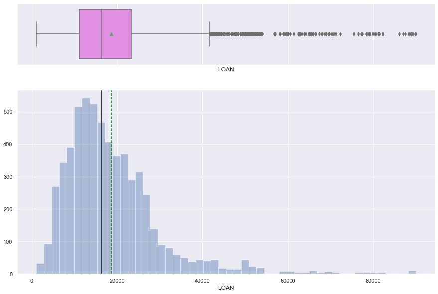

```python
# Build the histogram boxplot for Loan
histogram_boxplot(data['LOAN'])
```

**Insights**

- The distribution is skewed to the right and there are many outliers above 75 percentile. The mean is larger than the median.
- Since it is possible to have high loan for very expensive houses, we can leave these outliers untreated.
- Overall the distribution is close to a normal while the mean and median does not deviate too much.

#### **Note:** As done above, analyze Histogram and Boxplot for other variables

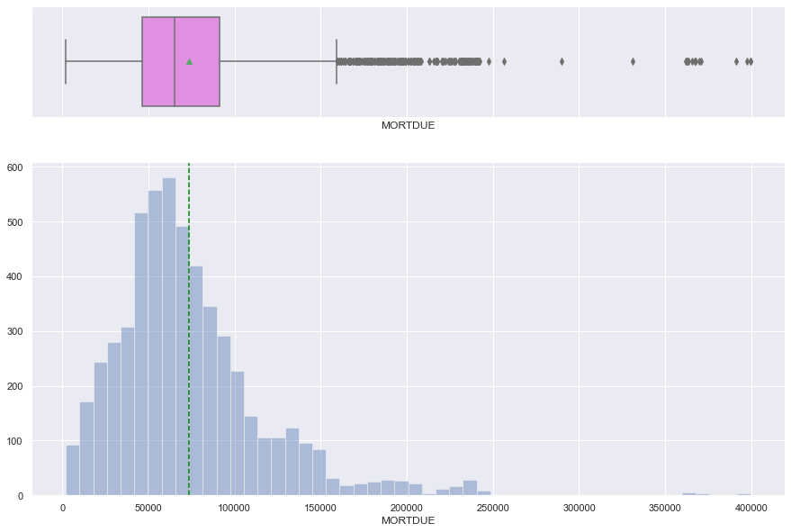

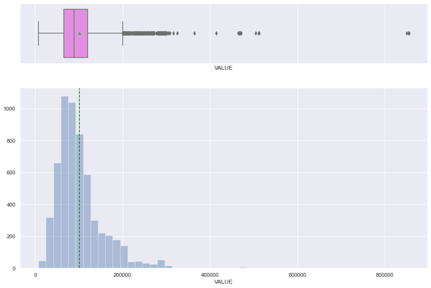

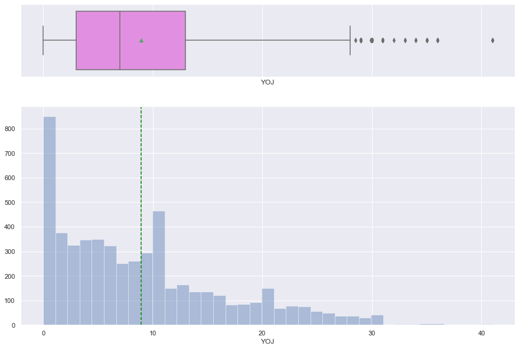

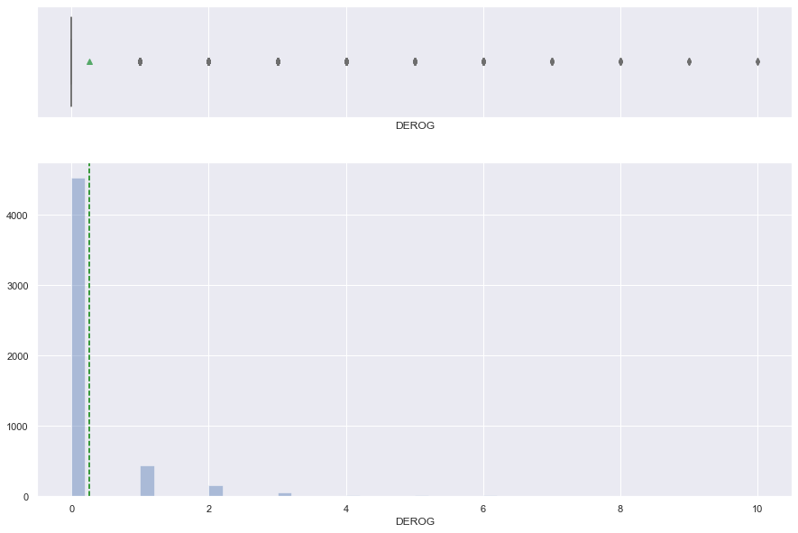

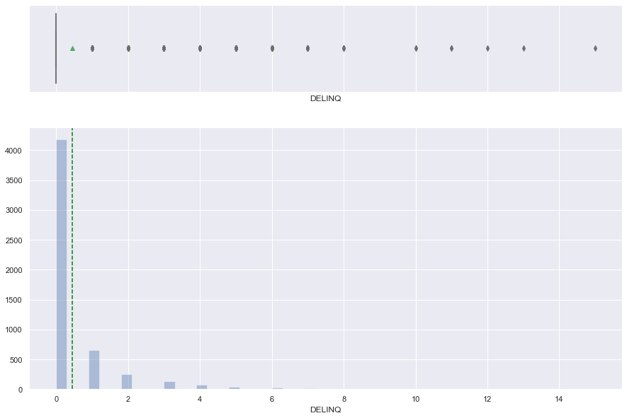

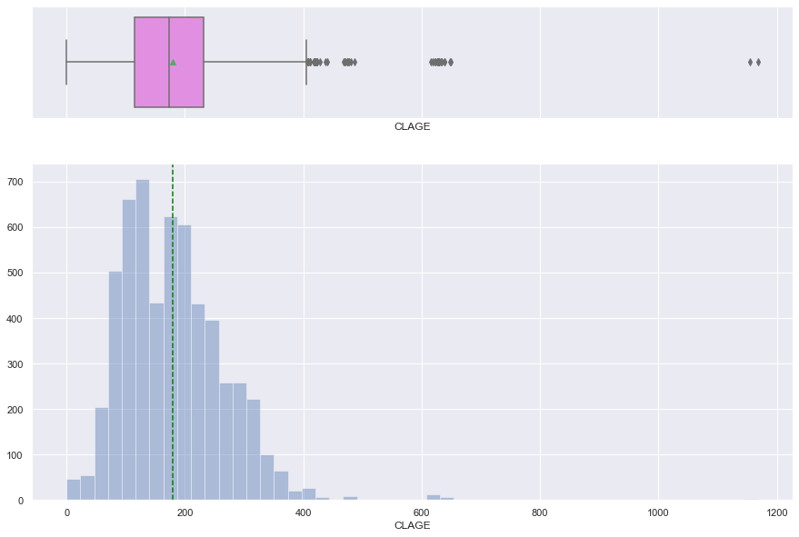

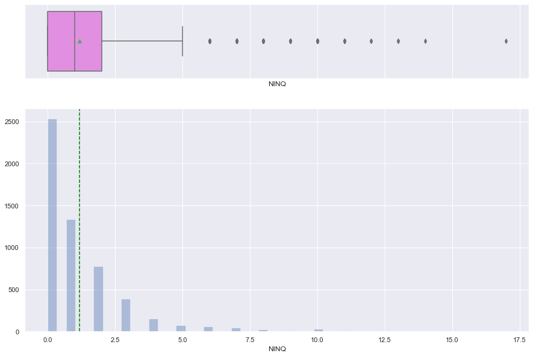

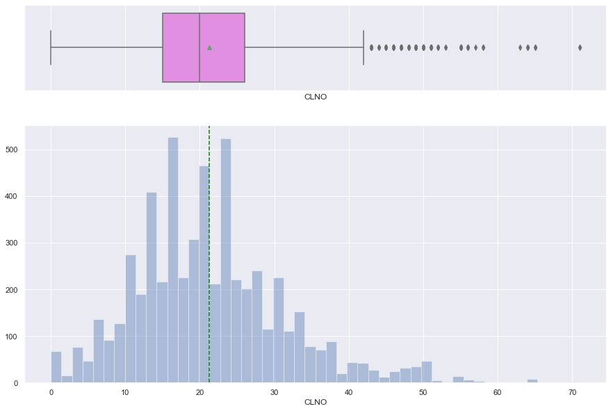

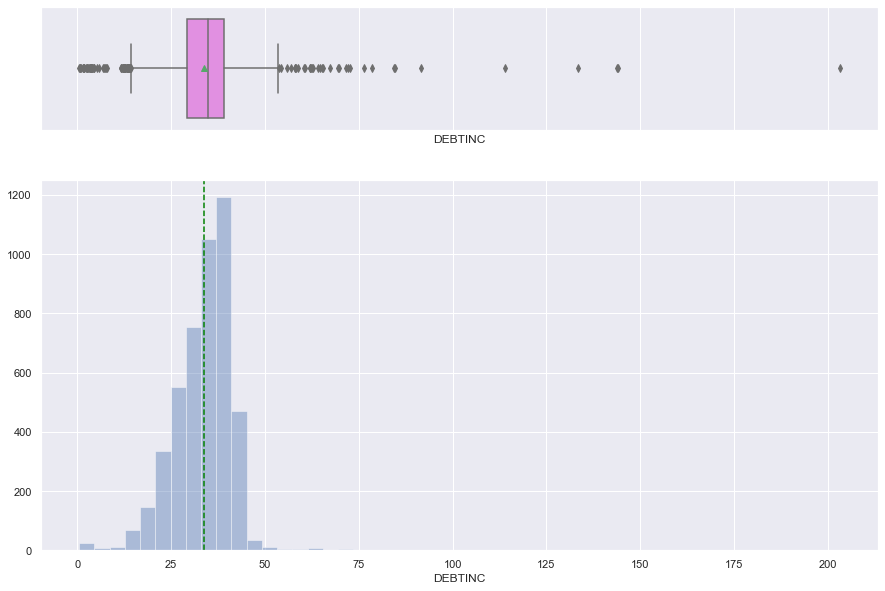

```python
NumList = ['MORTDUE', 'VALUE', 'YOJ', 'DEROG', 'DELINQ', 'CLAGE', 'NINQ', 'CLNO', 'DEBTINC']
for i in range(9):
    histogram_boxplot(data[NumList[i]])
```

**Insights**

- 'MORTDUE','VALUE' has many outliers on the right side and the distribution is right skewed
- 'YOJ' does not seem to be a normally distributed. Many clients have zero YOJ. The distribution is roughly downward sloping. There are some outliers on the right side, the distribution is heavyly right skewed.
- 'DEROG', 'DELINQ' are not continuous. Majority of clients have zero for these two columns the rest are all outliers. The distribution is skewed to the right
- 'CLAGE' is right skewed with two outliers that are extremely far away above 75 percentile, we need to take out these two outliers.
- 'NINQ' is not continuous and also right skewed with a few outliers on the right, we need to remove these outleirs from analysis
- 'CLNO' has some outliers on the right and we remove them
- 'DEBTINC' has outleirs on both sides, and it is roughly left skewed

### **2. Univariate Analysis - Categorical Data**

```python
# Function to create barplots that indicate percentage for each category.

def perc_on_bar(plot, feature):
    '''
    plot
    feature: categorical feature
    the function won't work if a column is passed in hue parameter
    '''

    total = len(feature) # length of the column
    for p in ax.patches:
        percentage = '{:.1f}%'.format(100 * p.get_height()/total) # percentage of each class of the category
        x = p.get_x() + p.get_width() / 2 - 0.05 # width of the plot
        y = p.get_y() + p.get_height()           # height of the plot
        ax.annotate(percentage, (x, y), size = 12) # annotate the percentage

    plt.show() # show the plot
```

#### Analyze Barplot for DELINQ

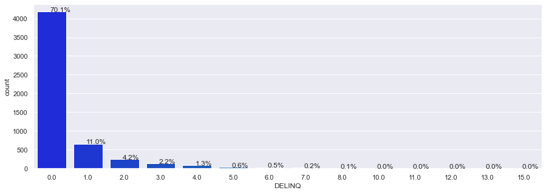

```python
#Build barplot for DELINQ

plt.figure(figsize=(15,5))
ax = sns.countplot(data["DELINQ"],palette='winter')
perc_on_bar(ax,data["DELINQ"])
```

**Insights**

- ~70% of the DELINQ value is 0, meaning no delinquent credit line exists for most clients.
- Around 11% of people have 1 delinquent account

#### Barplot is Great to Analyze Discrete Variables - DELINQ, DEROG, NINQ

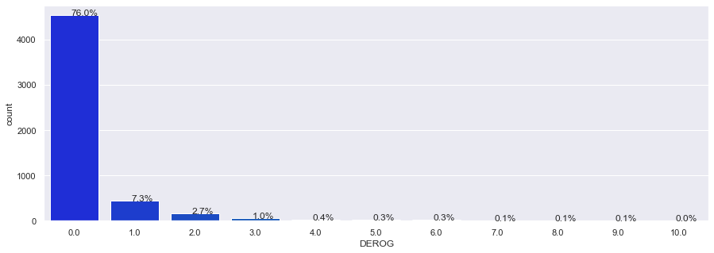

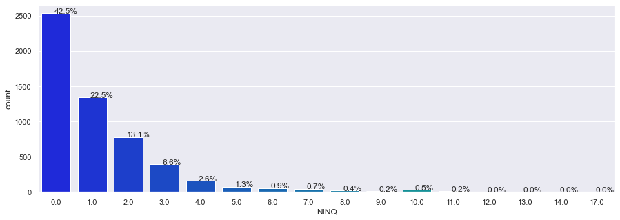

```python
list = ['DEROG', 'NINQ']
for i in list:
    plt.figure(figsize=(15,5))
    ax = sns.countplot(data[i],palette='winter')
    perc_on_bar(ax,data[i])
```

**Insights**

- ~76% of the DEROG value is 0, meaning no derogatory reports exists for most clients.
- Around 42.5% of the NINQ is 0, 22.5% is 1, and 13.1% is 2, meaning most people have fewer than 2 credit inquiries recently.

## **Bivariate Analysis**

### **Bivariate Analysis: Continuous and Categorical Variables**

#### Analyze BAD vs Loan

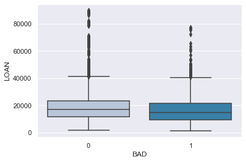

```python
sns.boxplot(data["BAD"],data['LOAN'],palette="PuBu")
```

**Insights**

- The range of loan for non-default loan is larger than defaulted loan.
- The average loan amount for non-default loan is higher than defaulted loan.
- Overall loan amount for non-default loan is more than defaulted, shown by the 25 and 75 percentile
- Most loan are below 40000 for both default and non-defaulted loan

#### **Note:** As shown above, perform Bi-Variate Analysis on different pair of Categorical and continuous variables

#### Analyze BAD vs DEROG vs DELINQ

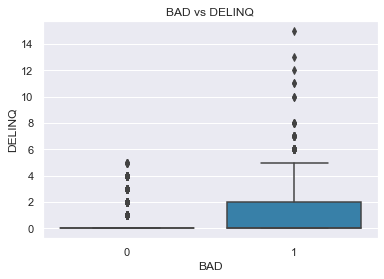

```python
sns.boxplot(data["BAD"],data['DELINQ'],palette="PuBu")
plt.title('BAD vs DELINQ')
```

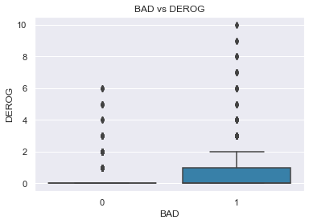

```python
sns.boxplot(data["BAD"],data['DEROG'],palette="PuBu")
plt.title('BAD vs DEROG')
```

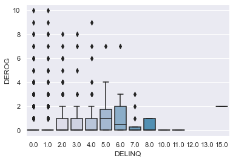

```python
#High Delinq also associate with high Derog. (0-1 delinq all derog > 0 are outliers)
sns.boxplot(data['DELINQ'],data['DEROG'],palette="PuBu")
```

**Insights**

- A few outliers do not default on loan but have high amount of delinquency credit lines or derogatory reports
- Default loan have a high tendency to associate with people who have high amount of delinquency credit lines or derogatory reports
- People who have high delinquency credit lines are also likely to have derogatory reports

### **Bivariate Analysis: Two Continuous Variables**

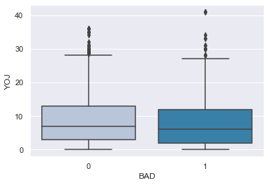

```python
sns.boxplot(data['BAD'],data['YOJ'],palette="PuBu")
```

**Insights:**

- people who do not default on their loan tend to have higher years of working experience
- There are some outliers who have very high years of experience still default on their loan

#### **Note:** As shown above, perform Bivariate Analysis on different pairs of continuous variables

#### Analyze BAD vs CLAGE

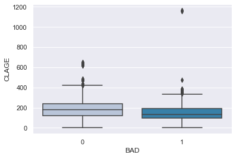

```python
sns.boxplot(data['BAD'],data['CLAGE'],palette="PuBu")
```

**Insights**

- People who default tend to have lower age of credit history. However there are some outliers that have very high credit history but still default.

#### Analyze BAD vs DEBTINC

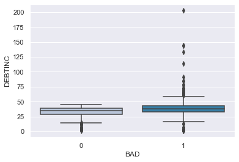

```python
sns.boxplot(data['BAD'],data['DEBTINC'],palette="PuBu")
```

**Insights**

- People who default tend to have higher Debt to income ratio, with some outliers that have extremely high (>100) debt to income ratio.

#### Analyze BAD vs CLNO

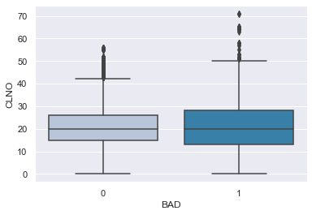

```python
sns.boxplot(data['BAD'],data['CLNO'],palette="PuBu")
```

**Insights**

- People who default have similar median number of existing credit. However, the 75 percentile and outliers shows that default people tend to have higher extreme value of existing credit than non-default people.

### **Bivariate Analysis: BAD vs Categorical Variables**

**The stacked bar chart (aka stacked bar graph)** extends the standard bar chart from looking at numeric values across one categorical variable to two.

```python
### Function to plot stacked bar charts for categorical columns

def stacked_plot(x):
    sns.set(palette='rocket_r')
    tab1 = pd.crosstab(x,data['BAD'],margins=True)
    print(tab1)
    print('-'*120)
    tab = pd.crosstab(x,data['BAD'],normalize='index')
    tab.plot(kind='bar',stacked=True,figsize=(10,5))
    plt.legend(loc='lower left', frameon=False)
    plt.legend(loc="upper left", bbox_to_anchor=(1,1))
    plt.show()
```

```
BAD         0     1   All
REASON
DebtCon  3183   745  3928
HomeImp  1384   396  1780
All      4567  1141  5708
------------------------------------------------------------------------------------------------------------------------
```

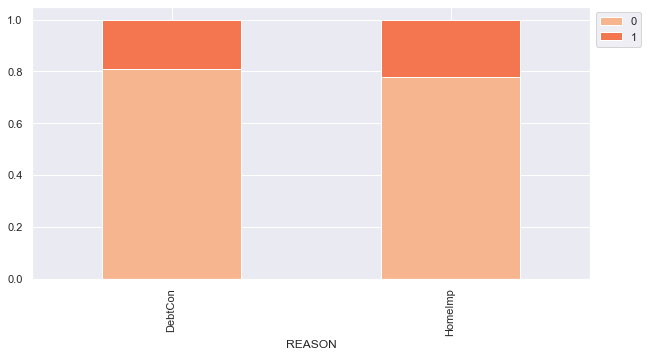

```python
# Plot stacked bar plot for BAD and REASON
stacked_plot(data['REASON'])
```

**Insights**

- around 18% people with debt consolidation default on loan, around 22% people with home improvement default on loan
- People who has home improvement are more likely to default than debt consolidation

#### **Note:** As shown above, perform Bivariate Analysis on different pairs of Categorical vs BAD

```
BAD         0     1   All
JOB
Mgr       588   179   767
Office    823   125   948
Other    1834   554  2388
ProfExe  1064   212  1276
Sales      71    38   109
Self      135    58   193
All      4515  1166  5681
------------------------------------------------------------------------------------------------------------------------
```

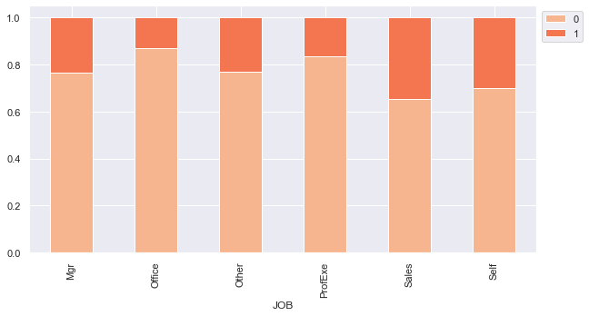

```python
# Plot stacked bar plot for BAD and JOB
stacked_plot(data['JOB'])
```

**Insights**

- People who has a job of Sales are most likely to default; People who are self employeed are also likely to default.
- However, since the sample size for sales and self are very low, we need to utilize other methods to support our thesis
- People who work in office are least likely to default

### **Multivariate Analysis**

#### Analyze Correlation Heatmap for Numerical Variables

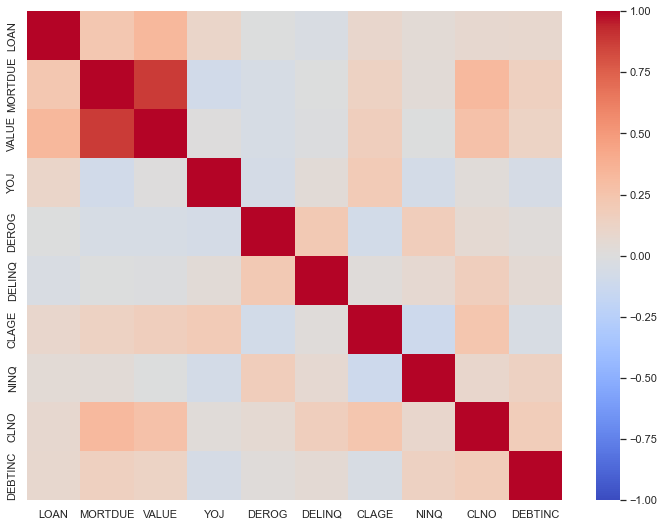

```python
# Separating numerical variables
numerical_col = data.select_dtypes(include=np.number).columns.tolist()

# Build correlation matrix for numerical columns
corr = data[numerical_col].corr()

# plot the heatmap
plt.figure(figsize=(12,9))
sns.heatmap(corr,cmap='coolwarm',vmax=1,vmin=-1,
        fmt=".2f",
        xticklabels=corr.columns,
        yticklabels=corr.columns);
```

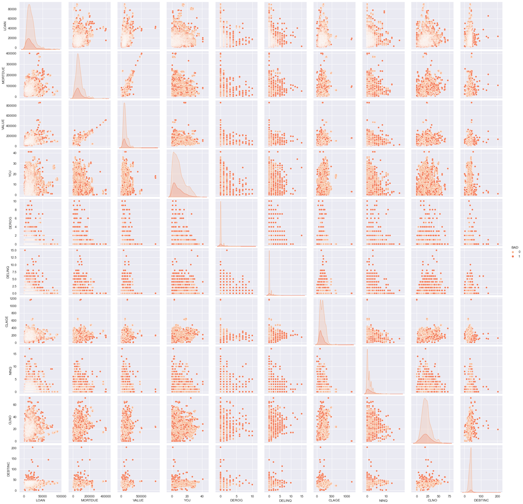

```python
# Build pairplot for the data with hue = 'BAD'
sns.pairplot(data,hue='BAD')
```

### **Think about it**

- Are there missing values and outliers in the dataset? If yes, how can you treat them?
- Can you think of different ways in which this can be done and when to treat these outliers or not?
- Can we create new features based on Missing values?

#### Treating Outliers

```python
def treat_outliers(df,col):
    '''
    treats outliers in a varaible
    col: str, name of the numerical varaible
    df: data frame
    col: name of the column
    '''

    Q1=df.quantile(0.25) # 25th quantile
    Q3=df.quantile(0.75)  # 75th quantile
    IQR=Q3-Q1   # IQR Range
    Lower_Whisker = Q1 - 1.5*IQR  #define lower whisker
    Upper_Whisker = Q3 + 1.5*IQR  # define upper Whisker
    df[col] = np.clip(df[col], Lower_Whisker, Upper_Whisker)
    # all the values samller than Lower_Whisker will be assigned value of Lower_whisker
    # and all the values above upper_whishker will be assigned value of upper_Whisker
    return df

def treat_outliers_all(df, col_list):
    '''
    treat outlier in all numerical varaibles
    col_list: list of numerical varaibles
    df: data frame
    '''
    for c in col_list:
        df = treat_outliers(df,c)

    return df
```

```python
df_raw = data.copy()

numerical_col = df_raw.select_dtypes(include=np.number).columns.tolist()# getting list of numerical columns

df = treat_outliers_all(df_raw,numerical_col)
```

#### Adding new columns in the dataset for each column which has missing values

```python
#For each column we create a binary flag for the row, if there is missing value in the row, then 1 else 0.
def add_binary_flag(df,col):
    '''
    df: It is the dataframe
    col: it is column which has missing values
    It returns a dataframe which has binary falg for missing values in column col
    '''
    new_col = str(col)
    new_col += '_missing_values_flag'
    df[new_col] = df[col].isna()
    return df
```

```python
# list of columns that has missing values in it
missing_col = [col for col in df.columns if df[col].isnull().any()]

for colmn in missing_col:
    add_binary_flag(df,colmn)
```

```python
data.select_dtypes('number')
```

|  | LOAN | MORTDUE | VALUE | YOJ | DEROG | DELINQ | CLAGE | NINQ | CLNO | DEBTINC |
| --- | --- | --- | --- | --- | --- | --- | --- | --- | --- | --- |
| 0 | 1100 | 25860.0 | 39025.0 | 10.5 | 0.0 | 0.0 | 94.366667 | 1.0 | 9.0 | NaN |
| 1 | 1300 | 70053.0 | 68400.0 | 7.0 | 0.0 | 2.0 | 121.833333 | 0.0 | 14.0 | NaN |
| 2 | 1500 | 13500.0 | 16700.0 | 4.0 | 0.0 | 0.0 | 149.466667 | 1.0 | 10.0 | NaN |
| 3 | 1500 | NaN | NaN | NaN | NaN | NaN | NaN | NaN | NaN | NaN |
| 4 | 1700 | 97800.0 | 112000.0 | 3.0 | 0.0 | 0.0 | 93.333333 | 0.0 | 14.0 | NaN |
| ... | ... | ... | ... | ... | ... | ... | ... | ... | ... | ... |
| 5955 | 88900 | 57264.0 | 90185.0 | 16.0 | 0.0 | 0.0 | 221.808718 | 0.0 | 16.0 | 36.112347 |
| 5956 | 89000 | 54576.0 | 92937.0 | 16.0 | 0.0 | 0.0 | 208.692070 | 0.0 | 15.0 | 35.859971 |
| 5957 | 89200 | 54045.0 | 92924.0 | 15.0 | 0.0 | 0.0 | 212.279697 | 0.0 | 15.0 | 35.556590 |
| 5958 | 89800 | 50370.0 | 91861.0 | 14.0 | 0.0 | 0.0 | 213.892709 | 0.0 | 16.0 | 34.340882 |
| 5959 | 89900 | 48811.0 | 88934.0 | 15.0 | 0.0 | 0.0 | 219.601002 | 0.0 | 16.0 | 34.571519 |

5960 rows × 10 columns

#### Filling missing values in numerical columns with median and mode in categorical variables

```python
#  Treat Missing values in numerical columns with median and mode in categorical variables
# Select numeric columns.
num_data = data.select_dtypes('number')

# Select string and object columns.
cat_data = data.select_dtypes('category').columns.tolist()#df.select_dtypes('object')

# Fill numeric columns with median.
data[num_data.columns] = num_data.fillna(data[num_data.columns].median())

# Fill object columns with mode.
for column in cat_data:
    mode = data[column].mode()[0]
    data[column] = data[column].fillna(mode)
```

```python
data.head(10)
```

|  | BAD | LOAN | MORTDUE | VALUE | REASON | JOB | YOJ | DEROG | DELINQ | CLAGE | NINQ | CLNO | DEBTINC |
| --- | --- | --- | --- | --- | --- | --- | --- | --- | --- | --- | --- | --- | --- |
| 0 | 1 | 1100 | 25860.0 | 39025.0 | HomeImp | Other | 10.5 | 0.0 | 0.0 | 94.366667 | 1.0 | 9.0 | 34.818262 |
| 1 | 1 | 1300 | 70053.0 | 68400.0 | HomeImp | Other | 7.0 | 0.0 | 2.0 | 121.833333 | 0.0 | 14.0 | 34.818262 |
| 2 | 1 | 1500 | 13500.0 | 16700.0 | HomeImp | Other | 4.0 | 0.0 | 0.0 | 149.466667 | 1.0 | 10.0 | 34.818262 |
| 3 | 1 | 1500 | 65019.0 | 89235.5 | DebtCon | Other | 7.0 | 0.0 | 0.0 | 173.466667 | 1.0 | 20.0 | 34.818262 |
| 4 | 0 | 1700 | 97800.0 | 112000.0 | HomeImp | Office | 3.0 | 0.0 | 0.0 | 93.333333 | 0.0 | 14.0 | 34.818262 |
| 5 | 1 | 1700 | 30548.0 | 40320.0 | HomeImp | Other | 9.0 | 0.0 | 0.0 | 101.466002 | 1.0 | 8.0 | 37.113614 |
| 6 | 1 | 1800 | 48649.0 | 57037.0 | HomeImp | Other | 5.0 | 3.0 | 2.0 | 77.100000 | 1.0 | 17.0 | 34.818262 |
| 7 | 1 | 1800 | 28502.0 | 43034.0 | HomeImp | Other | 11.0 | 0.0 | 0.0 | 88.766030 | 0.0 | 8.0 | 36.884894 |
| 8 | 1 | 2000 | 32700.0 | 46740.0 | HomeImp | Other | 3.0 | 0.0 | 2.0 | 216.933333 | 1.0 | 12.0 | 34.818262 |
| 9 | 1 | 2000 | 65019.0 | 62250.0 | HomeImp | Sales | 16.0 | 0.0 | 0.0 | 115.800000 | 0.0 | 13.0 | 34.818262 |

```python
data.isnull().sum()
```

```
BAD        0
LOAN       0
MORTDUE    0
VALUE      0
REASON     0
JOB        0
YOJ        0
DEROG      0
DELINQ     0
CLAGE      0
NINQ       0
CLNO       0
DEBTINC    0
dtype: int64
```

## **Proposed approach**

**1. Potential techniques** - What different techniques should be explored?

- Model - Decision Tree, Random Forest, logistic regression, Support Vector Machine, KNN. These are popular classification machine learning models.
- We will use train-test split or k-fold cross-validation to train & test our model and find the best hyperparameters.
- We can also use PCA and TSNE to reduce dimension of our data and identify the most significant features. However, since we only have 10 columns, it is not really necessary to use PCA

**2. Overall solution design** - What is the potential solution design?

- The data is fully-prepared for modeling. We will first split the dataset to train and test set(20% Test, 80% Train) or use k-fold to split into multiple train-test sets.
- We then train different models on the training set, check the evaluation matrix of our models on training data and testing data, and determine which measurement to maximize.
- We will then tune the models using gridsearch method under different hyperparameters to find the best working model.
- Finally, we will run the model and check the most important features
- We will then evaluate these features to see if they are reasonable, and recommend our model and features to management team.

**3. Measures of success** - What are the key measures of success?

- We can use model evaluation methods like confusion matrix, jaccard_score, precision, recall, f1-score to measure our success.
- We can also investigate features importance to make sure the top features we find are reasonable.